# Real-world Data Wrangling

## 1. Gather data

```python
!pip install kagglehub
```

```
     ━━━━━━━━━━━━━━━━━━━━━━━━━━━━━━━━━━━━━━━ 51.9/51.9 kB 939.5 kB/s eta 0:00:000:01
```

```python
import kagglehub
import pandas as pd
import matplotlib.pyplot as plt
from datetime import datetime
```

### **1.1.** Problem Statement

#### 1- : Which items (item_id) are discounted most frequently, and in which stores (store_id)?

#### 2- : How do prices of items (price) vary across time (Year)?

#### 3- : Which stores (store_id) have the highest average item prices?

### **1.2.** Gather at least two datasets using two different data gathering methods

In this project, I have decided to gather the datasets using the manual as well as programatic download methods through Kagglehup.

#### **Dataset 1**

Type: *CSV file*

File name : *price_history*

Method: *Kagglehub* https://www.kaggle.com/datasets/svizor/retail-sales-forecasting-data?select=price_history.csv

Dataset variables:

```python
path = kagglehub.dataset_download("svizor/retail-sales-forecasting-data")
df_price = pd.read_csv(path + "/price_history.csv")
df_price.head()
```

```
Downloading from https://www.kaggle.com/api/v1/datasets/download/svizor/retail-sales-forecasting-data?dataset_version_number=1...
```

```
Extracting files...
```

|  | Unnamed: 0 | date | item_id | price | code | store_id |
| --- | --- | --- | --- | --- | --- | --- |
| 0 | 0 | 2023-08-01 | 4a1f95fe4d4b | 499.9 | 1 | 1 |
| 1 | 1 | 2023-08-01 | bf43a9d3ae13 | 0.0 | 9999999999 | 1 |
| 2 | 2 | 2023-08-01 | 0dd8744decce | 129.9 | 1 | 1 |
| 3 | 3 | 2023-08-01 | 9b38c7e4dba9 | 136.0 | 1 | 1 |
| 4 | 4 | 2023-08-01 | b791e8c9347c | 0.0 | 1 | 1 |

#### Dataset 2

Type: *CSV file*

File name: discount_history

Method: *manual Dwonload* the data gathered manual from https://www.kaggle.com/datasets/svizor/retail-sales-forecasting-data?resource=download&select=discounts_history.csv

Dataset variables:

- date: The date when the price data was recorded.
- item_id: The unique identifier for the item.
- sale_price_before_promo: The price of the item before any promotional discount.
- sale_price_time_promo: The price of the item during the promotional period.
- promo_type_code: The code for the type of promotion applied to the item.
- doc_id: The unique identifier for the promotional document (such as a promotion record).
- number_disc_day: The number of days the item was on promotion.
- store_id: The unique identifier for the store.

```python
df_discount = pd.read_csv("discounts_history.csv")
df_discount.head()
```

|  | Unnamed: 0 | date | item_id | sale_price_before_promo | sale_price_time_promo | promo_type_code | doc_id | number_disc_day | store_id |
| --- | --- | --- | --- | --- | --- | --- | --- | --- | --- |
| 0 | 3648316 | 2022-08-28 | cde97a9ec3ef | 729.9 | 669.9 | 6.0 | 89ea9f0c-1c08-11ed-ad4d-005056861040 | 13.0 | 1 |
| 1 | 3648317 | 2022-08-28 | 2906fbc9e11c | 129.9 | 99.9 | NaN | 039e85df-1e51-11ed-ad4d-005056861040 | 11.0 | 1 |
| 2 | 3648318 | 2022-08-28 | c48c3a3d8c01 | 129.9 | 99.9 | NaN | 039e85df-1e51-11ed-ad4d-005056861040 | 11.0 | 1 |
| 3 | 3648319 | 2022-08-28 | f85243ca61e6 | 129.9 | 99.9 | NaN | 039e85df-1e51-11ed-ad4d-005056861040 | 11.0 | 1 |
| 4 | 3648320 | 2022-08-28 | 27ce75534065 | 129.9 | 99.9 | NaN | 039e85df-1e51-11ed-ad4d-005056861040 | 11.0 | 1 |

```python
# Save the raw data to a CSV file
df_price.to_csv('df_price_raw.csv', index=False)
df_discount.to_csv('df_discount_raw.csv', index=False)
```

## 2. Assess data

### Completeness :

```python
df_price.head()
```

|  | Unnamed: 0 | date | item_id | price | code | store_id |
| --- | --- | --- | --- | --- | --- | --- |
| 0 | 0 | 2023-08-01 | 4a1f95fe4d4b | 499.9 | 1 | 1 |
| 1 | 1 | 2023-08-01 | bf43a9d3ae13 | 0.0 | 9999999999 | 1 |
| 2 | 2 | 2023-08-01 | 0dd8744decce | 129.9 | 1 | 1 |
| 3 | 3 | 2023-08-01 | 9b38c7e4dba9 | 136.0 | 1 | 1 |
| 4 | 4 | 2023-08-01 | b791e8c9347c | 0.0 | 1 | 1 |

```python
df_price.tail()
```

|  | Unnamed: 0 | date | item_id | price | code | store_id |
| --- | --- | --- | --- | --- | --- | --- |
| 698621 | 1885028 | 2024-09-26 | 7586d4f4599e | 479.9 | 10 | 4 |
| 698622 | 1885029 | 2024-09-26 | 4b7ea164af56 | 359.9 | 31 | 4 |
| 698623 | 1885030 | 2024-09-26 | c1b874b62220 | 359.9 | 10 | 4 |
| 698624 | 1885031 | 2024-09-26 | c1b874b62220 | 279.9 | 29 | 4 |
| 698625 | 1885032 | 2024-09-26 | 66dcdf3628de | 99.9 | 10 | 4 |

```python
df_price.sample(10)
```

|  | Unnamed: 0 | date | item_id | price | code | store_id |
| --- | --- | --- | --- | --- | --- | --- |
| 10941 | 10941 | 2023-08-25 | 36083eaac8ce | 999.9 | 1 | 1 |
| 25944 | 25944 | 2023-09-28 | 2709ec5407ca | 989.9 | 11 | 1 |
| 131996 | 131996 | 2024-06-19 | 253ab68ae78c | 699.9 | 9 | 1 |
| 522185 | 1625200 | 2023-12-15 | 08948ffb0e64 | 29.9 | 3 | 3 |
| 58896 | 58896 | 2023-12-07 | 12fbd3365b28 | 269.9 | 10 | 1 |
| 577484 | 1763891 | 2023-02-28 | c017b9238f7a | 189.9 | 14 | 3 |
| 12430 | 12430 | 2023-08-30 | 421f9c25a800 | 0.0 | 1 | 1 |
| 528405 | 1631420 | 2024-01-25 | 52a48f7a41e7 | 42.9 | 7 | 3 |
| 460156 | 1426913 | 2023-02-07 | 4db97ae0abdb | 74.0 | 1 | 2 |
| 562650 | 1749057 | 2022-10-29 | a4d248a0c9bb | 224.9 | 13 | 3 |

```python
df_discount.head()
```

|  | Unnamed: 0 | date | item_id | sale_price_before_promo | sale_price_time_promo | promo_type_code | doc_id | number_disc_day | store_id |
| --- | --- | --- | --- | --- | --- | --- | --- | --- | --- |
| 0 | 3648316 | 2022-08-28 | cde97a9ec3ef | 729.9 | 669.9 | 6.0 | 89ea9f0c-1c08-11ed-ad4d-005056861040 | 13.0 | 1 |
| 1 | 3648317 | 2022-08-28 | 2906fbc9e11c | 129.9 | 99.9 | NaN | 039e85df-1e51-11ed-ad4d-005056861040 | 11.0 | 1 |
| 2 | 3648318 | 2022-08-28 | c48c3a3d8c01 | 129.9 | 99.9 | NaN | 039e85df-1e51-11ed-ad4d-005056861040 | 11.0 | 1 |
| 3 | 3648319 | 2022-08-28 | f85243ca61e6 | 129.9 | 99.9 | NaN | 039e85df-1e51-11ed-ad4d-005056861040 | 11.0 | 1 |
| 4 | 3648320 | 2022-08-28 | 27ce75534065 | 129.9 | 99.9 | NaN | 039e85df-1e51-11ed-ad4d-005056861040 | 11.0 | 1 |

```python
df_discount.tail()
```

|  | Unnamed: 0 | date | item_id | sale_price_before_promo | sale_price_time_promo | promo_type_code | doc_id | number_disc_day | store_id |
| --- | --- | --- | --- | --- | --- | --- | --- | --- | --- |
| 3746739 | 11420928 | 2045-12-31 | 23b18d1f7da9 | 59.9 | 59.9 | NaN | baa3d490-5529-11ed-bb91-005056afbcf1 | 8766.0 | 4 |
| 3746740 | 11420929 | 2045-12-31 | e5b2b6f57ea7 | 59.9 | 59.9 | NaN | baa3d490-5529-11ed-bb91-005056afbcf1 | 8766.0 | 4 |
| 3746741 | 11420930 | 2045-12-31 | 2c007023f650 | 59.9 | 59.9 | NaN | baa3d490-5529-11ed-bb91-005056afbcf1 | 8766.0 | 4 |
| 3746742 | 11420931 | 2045-12-31 | 9f716dce9a57 | 59.9 | 59.9 | NaN | baa3d490-5529-11ed-bb91-005056afbcf1 | 8766.0 | 4 |
| 3746743 | 11420932 | 2045-12-31 | 99d388c37359 | 59.9 | 59.9 | NaN | baa3d490-5529-11ed-bb91-005056afbcf1 | 8766.0 | 4 |

```python
df_discount.sample(10)
```

|  | Unnamed: 0 | date | item_id | sale_price_before_promo | sale_price_time_promo | promo_type_code | doc_id | number_disc_day | store_id |
| --- | --- | --- | --- | --- | --- | --- | --- | --- | --- |
| 3725404 | 11399593 | 2036-04-06 | e5b2b6f57ea7 | 59.9 | 59.9 | NaN | baa3d490-5529-11ed-bb91-005056afbcf1 | 5210.0 | 4 |
| 708766 | 4357082 | 2023-06-14 | afe7348dc870 | 219.9 | 169.9 | 5.0 | b226a2bf-052b-11ee-bb93-005056afbcf1 | 7.0 | 1 |
| 211476 | 3859792 | 2022-12-03 | 0cb068222451 | 189.9 | 169.9 | 6.0 | 9e063e88-6b4a-11ed-bb91-005056afbcf1 | 10.0 | 1 |
| 1628988 | 5277304 | 2024-09-09 | 118e1421b096 | 24.9 | 24.9 | 5.0 | 5fc9cef3-65e3-11ef-bb94-005056afbcf1 | 12.0 | 1 |
| 2961725 | 10629128 | 2024-08-29 | a4577d85d50b | 39.9 | 39.9 | 5.0 | 6bc8a76c-6578-11ef-bb94-005056afbcf1 | 1.0 | 3 |
| 3258394 | 10932583 | 2024-03-15 | bb92d0a15557 | 112.9 | 89.9 | 6.0 | 82afb890-dfb8-11ee-bb94-005056afbcf1 | 2.0 | 4 |
| 991343 | 4639659 | 2023-11-03 | ab4544e5cbfb | 49.9 | 40.9 | 6.0 | e5ba277d-7241-11ee-bb94-005056afbcf1 | 9.0 | 1 |
| 1516976 | 5165292 | 2024-07-20 | 5bbcd6fadbfb | 649.9 | 549.9 | 6.0 | f0d36cae-3f87-11ef-bb94-005056afbcf1 | 5.0 | 1 |
| 439880 | 4088196 | 2023-03-03 | 438b13f55a03 | 66.9 | 59.9 | 6.0 | 144be0b2-b84d-11ed-bb93-005056afbcf1 | 2.0 | 1 |
| 291643 | 3939959 | 2023-01-03 | 1aab07a2a659 | 169.9 | 119.9 | 10.0 | 5b2a599a-815b-11ed-bb93-005056afbcf1 | 13.0 | 1 |

```python
df_price.isnull().sum()
```

```
Unnamed: 0    0
date          0
item_id       0
price         0
code          0
store_id      0
dtype: int64
```

```python
df_discount.isnull().sum()
```

```
Unnamed: 0                      0
date                            0
item_id                         0
sale_price_before_promo         0
sale_price_time_promo           0
promo_type_code            317846
doc_id                          0
number_disc_day                 0
store_id                        0
dtype: int64
```

### Completeness Summary

- We found 317846 null values in promo_type_code column in the discount_history data set

### Validity:

```python
df_price.sample(5)
```

|  | Unnamed: 0 | date | item_id | price | code | store_id |
| --- | --- | --- | --- | --- | --- | --- |
| 256187 | 730164 | 2023-03-15 | ef98b37ac335 | 189.9 | 35 | 1 |
| 612438 | 1798845 | 2024-02-06 | 50ac963e78da | 0.0 | 9999999999 | 4 |
| 545049 | 1648064 | 2024-05-30 | 3fc7b7e05031 | 157.9 | 1 | 3 |
| 448623 | 1415380 | 2022-12-06 | de16503a8d18 | 74.9 | 11 | 2 |
| 197244 | 671221 | 2022-11-07 | 714fb980d919 | 479.9 | 12 | 1 |

```python
df_discount.sample(5)
```

|  | Unnamed: 0 | date | item_id | sale_price_before_promo | sale_price_time_promo | promo_type_code | doc_id | number_disc_day | store_id |
| --- | --- | --- | --- | --- | --- | --- | --- | --- | --- |
| 1319856 | 4968172 | 2024-04-23 | ec06b1e90b65 | 429.9 | 429.9 | 5.0 | ae6b375f-f755-11ee-bb94-005056afbcf1 | 13.0 | 1 |
| 952547 | 4600863 | 2023-10-05 | b0ea19adbd90 | 69.9 | 69.9 | 5.0 | fdcc4350-5d45-11ee-bb94-005056afbcf1 | 8.0 | 1 |
| 2078847 | 7727689 | 2023-08-16 | 0fc865b332ad | 167.9 | 96.9 | 6.0 | 1733c8b8-3127-11ee-bb94-005056afbcf1 | 14.0 | 2 |
| 3489013 | 11163202 | 2024-07-03 | 055c740a4c62 | 479.9 | 399.9 | 5.0 | bd7500b0-38f7-11ef-bb94-005056afbcf1 | 1.0 | 4 |
| 3271668 | 10945857 | 2024-03-21 | 594a408253cf | 2799.9 | 1999.9 | 6.0 | bd1992ca-e142-11ee-bb94-005056afbcf1 | 3.0 | 4 |

```python
df_price.dtypes
```

```
Unnamed: 0      int64
date           object
item_id        object
price         float64
code            int64
store_id        int64
dtype: object
```

```python
df_discount.dtypes
```

```
Unnamed: 0                   int64
date                        object
item_id                     object
sale_price_before_promo    float64
sale_price_time_promo      float64
promo_type_code            float64
doc_id                      object
number_disc_day            float64
store_id                     int64
dtype: object
```

### validity summary

- We found inconsistent data types in the date column, which is stored as an object instead of a datetime type, affecting date-based operations and analysis.

### Duplicates:

```python
df_discount.sample(10)
```

|  | Unnamed: 0 | date | item_id | sale_price_before_promo | sale_price_time_promo | promo_type_code | doc_id | number_disc_day | store_id |
| --- | --- | --- | --- | --- | --- | --- | --- | --- | --- |
| 2818961 | 10486364 | 2024-02-28 | 48f21b0c5624 | 34.9 | 34.9 | 5.0 | c37a376d-cb6a-11ee-bb94-005056afbcf1 | 14.0 | 3 |
| 3064176 | 10738365 | 2023-07-31 | fa1c0ece7e1e | 74.9 | 54.9 | 6.0 | 8bd1d673-fbd7-11ee-bb94-005056afbcf1 | 472.0 | 4 |
| 312701 | 3961017 | 2023-01-10 | c428c02b9b8e | 59.9 | 49.9 | 6.0 | 4bd84294-815b-11ed-bb93-005056afbcf1 | 20.0 | 1 |
| 44494 | 3692810 | 2022-09-18 | ab7e16e1fffb | 1499.9 | 1099.9 | 6.0 | f8f4a560-344b-11ed-ad4d-005056861040 | 4.0 | 1 |
| 1793900 | 7442742 | 2022-10-11 | 6790437682c8 | 79.9 | 59.9 | 5.0 | 51358582-3f2a-11ed-ad4d-005056861040 | 13.0 | 2 |
| 1704259 | 5352575 | 2026-06-11 | e5b2b6f57ea7 | 59.9 | 59.9 | NaN | baa3d490-5529-11ed-bb91-005056afbcf1 | 1623.0 | 1 |
| 3231610 | 10905799 | 2024-03-02 | 92001e1a5a9a | 259.9 | 219.9 | 5.0 | 2bb1ad75-d484-11ee-bb94-005056afbcf1 | 5.0 | 4 |
| 1725316 | 5373632 | 2030-11-16 | 9c9221fd01bc | 1490.0 | 990.0 | NaN | 09bb9bad-8a6d-11ec-b591-005056861040 | 3201.0 | 1 |
| 351285 | 3999601 | 2023-01-27 | 946a2df0c965 | 57.9 | 44.9 | 6.0 | fe2aa771-974b-11ed-bb93-005056afbcf1 | 9.0 | 1 |
| 1248259 | 4896575 | 2024-03-22 | 2472c6e0775d | 35.9 | 25.9 | 5.0 | 4266c45a-e6c6-11ee-bb94-005056afbcf1 | 2.0 | 1 |

```python
df_price.sample(10)
```

|  | Unnamed: 0 | date | item_id | price | code | store_id |
| --- | --- | --- | --- | --- | --- | --- |
| 668126 | 1854533 | 2024-07-05 | f928a76672ab | 259.9 | 1 | 4 |
| 210394 | 684371 | 2022-11-30 | e2d816701cab | 59.9 | 14 | 1 |
| 287745 | 761722 | 2023-05-24 | f5e68ca47c16 | 379.9 | 35 | 1 |
| 424749 | 1391506 | 2022-08-29 | 2354ed80015a | 134.9 | 35 | 2 |
| 326188 | 1038424 | 2023-08-03 | 4ec226b1494a | 85.9 | 10 | 2 |
| 464630 | 1431387 | 2023-03-02 | 5963039b620b | 479.0 | 10 | 2 |
| 209318 | 683295 | 2022-11-28 | 9b4f09758b41 | 649.9 | 35 | 1 |
| 201634 | 675611 | 2022-11-09 | 9e6f391d2f4e | 69.9 | 35 | 1 |
| 336657 | 1048893 | 2023-09-27 | 5cb50337b463 | 399.8 | 35 | 2 |
| 664054 | 1850461 | 2024-06-27 | 836bf8db7254 | 113.9 | 13 | 4 |

```python
df_price.duplicated().sum()
```

```
0
```

```python
df_discount.duplicated().sum()
```

```
0
```

### Uniqueness Summary

- We found no duplications.

## Tideness

### Non-Atomic Columns (doc_id):

```python
df_price.sample(5)
```

|  | Unnamed: 0 | date | item_id | price | code | store_id |
| --- | --- | --- | --- | --- | --- | --- |
| 629401 | 1815808 | 2024-03-20 | e7e1d4962d46 | 249.9 | 7 | 4 |
| 695578 | 1881985 | 2024-09-23 | b64cf0efca45 | 1999.9 | 9 | 4 |
| 365608 | 1077844 | 2024-01-10 | b522c3cb37da | 249.9 | 31 | 2 |
| 459289 | 1426046 | 2023-01-31 | cd1e062d7477 | 62.0 | 1 | 2 |
| 286555 | 760532 | 2023-05-25 | b1a1f407c27e | 339.9 | 10 | 1 |

```python
df_discount.sample(5)
```

|  | Unnamed: 0 | date | item_id | sale_price_before_promo | sale_price_time_promo | promo_type_code | doc_id | number_disc_day | store_id |
| --- | --- | --- | --- | --- | --- | --- | --- | --- | --- |
| 52487 | 3700803 | 2022-09-22 | ed07ac53e67f | 149.9 | 129.9 | 6.0 | f8f4a560-344b-11ed-ad4d-005056861040 | 8.0 | 1 |
| 1404905 | 5053221 | 2024-05-31 | b7a2ddb9141a | 349.9 | 249.9 | 5.0 | d9a3b5a7-1805-11ef-bb94-005056afbcf1 | 10.0 | 1 |
| 2564319 | 10231722 | 2022-10-03 | 2310f068af26 | 369.9 | 329.9 | 6.0 | b1060c91-3da2-11ed-ad4d-005056861040 | 7.0 | 3 |
| 3358251 | 11032440 | 2024-05-01 | 59e74245e91e | 75.9 | 75.9 | 5.0 | 68d11319-0494-11ef-bb94-005056afbcf1 | 7.0 | 4 |
| 2485838 | 8134680 | 2025-04-10 | c18d20ea2baa | 2990.0 | 990.0 | NaN | eb346b65-477f-11ec-b263-005056861040 | 1288.0 | 2 |

```python
df_discount.columns
```

```
Index(['Unnamed: 0', 'date', 'item_id', 'sale_price_before_promo',
       'sale_price_time_promo', 'promo_type_code', 'doc_id', 'number_disc_day',
       'store_id'],
      dtype='object')
```

### Standardizing Date Format and Structure:

```python
df_price.sample(5)
```

|  | Unnamed: 0 | date | item_id | price | code | store_id |
| --- | --- | --- | --- | --- | --- | --- |
| 244687 | 718664 | 2023-02-16 | 1372dd1bc897 | 329.9 | 10 | 1 |
| 13471 | 13471 | 2023-08-31 | bbcd1442a559 | 0.0 | 1 | 1 |
| 120796 | 120796 | 2024-05-21 | 6b6ba622256b | 549.9 | 1 | 1 |
| 593207 | 1779614 | 2023-12-19 | 04f8c0cec44c | 1499.9 | 31 | 4 |
| 684911 | 1871318 | 2024-08-25 | 4bdd5b670678 | 59.9 | 11 | 4 |

```python
df_discount.sample(5)
```

|  | Unnamed: 0 | date | item_id | sale_price_before_promo | sale_price_time_promo | promo_type_code | doc_id | number_disc_day | store_id |
| --- | --- | --- | --- | --- | --- | --- | --- | --- | --- |
| 802584 | 4450900 | 2023-07-20 | 43efaf86caaa | 319.9 | 239.9 | 5.0 | 0ba11a57-265c-11ee-bb94-005056afbcf1 | 1.0 | 1 |
| 174940 | 3823256 | 2022-11-17 | 6e4f919617bf | 1099.9 | 699.9 | 5.0 | 3da5dda7-5eb2-11ed-bb91-005056afbcf1 | 10.0 | 1 |
| 2964324 | 10631727 | 2024-09-02 | 423fe9206040 | 229.9 | 189.9 | 6.0 | 72145daf-6578-11ef-bb94-005056afbcf1 | 5.0 | 3 |
| 2623502 | 10290905 | 2023-02-08 | f93a98e17bfd | 299.9 | 199.9 | 5.0 | cd65a97c-a2a2-11ed-bb93-005056afbcf1 | 7.0 | 3 |
| 1547163 | 5195479 | 2024-08-03 | 459c7814a693 | 249.9 | 199.9 | 6.0 | 0212c7d5-4e45-11ef-bb94-005056afbcf1 | 3.0 | 1 |

```python
df_price.info()
```

```
<class 'pandas.core.frame.DataFrame'>
RangeIndex: 698626 entries, 0 to 698625
Data columns (total 6 columns):
 #   Column      Non-Null Count   Dtype
---  ------      --------------   -----
 0   Unnamed: 0  698626 non-null  int64
 1   date        698626 non-null  object
 2   item_id     698626 non-null  object
 3   price       698626 non-null  float64
 4   code        698626 non-null  int64
 5   store_id    698626 non-null  int64
dtypes: float64(1), int64(3), object(2)
memory usage: 32.0+ MB
```

```python
df_discount.info()
```

```
<class 'pandas.core.frame.DataFrame'>
RangeIndex: 3746744 entries, 0 to 3746743
Data columns (total 9 columns):
 #   Column                   Dtype
---  ------                   -----
 0   Unnamed: 0               int64
 1   date                     object
 2   item_id                  object
 3   sale_price_before_promo  float64
 4   sale_price_time_promo    float64
 5   promo_type_code          float64
 6   doc_id                   object
 7   number_disc_day          float64
 8   store_id                 int64
dtypes: float64(4), int64(2), object(3)
memory usage: 257.3+ MB
```

##### I found that the dataset contains a single column called date, which includes the month, day, and year together. I observed that this would make it difficult to work with these components separately, as it would limit flexibility in analyzing or manipulating the data by individual date components.

## Tidiness Summary:

### Assessing Data Summary

Both datasets meet the key conditions of tidiness, where each variable is represented as a column and each observation forms a row. The datasets include relevant variables such as item_id, store_id, date, and others. However, there are some areas to address, like unnecessary columns (e.g., "Unnamed" columns)and missing values, These issues need to be cleaned for effective analysis.

## 3. Clean data

```python
# Make copies of the original datasets
df_price_copy = df_price.copy()
df_discount_copy = df_discount.copy()
```

```python
df_price_copy.head()
```

|  | Unnamed: 0 | date | item_id | price | code | store_id |
| --- | --- | --- | --- | --- | --- | --- |
| 0 | 0 | 2023-08-01 | 4a1f95fe4d4b | 499.9 | 1 | 1 |
| 1 | 1 | 2023-08-01 | bf43a9d3ae13 | 0.0 | 9999999999 | 1 |
| 2 | 2 | 2023-08-01 | 0dd8744decce | 129.9 | 1 | 1 |
| 3 | 3 | 2023-08-01 | 9b38c7e4dba9 | 136.0 | 1 | 1 |
| 4 | 4 | 2023-08-01 | b791e8c9347c | 0.0 | 1 | 1 |

```python
df_discount_copy.head()
```

|  | Unnamed: 0 | date | item_id | sale_price_before_promo | sale_price_time_promo | promo_type_code | doc_id | number_disc_day | store_id |
| --- | --- | --- | --- | --- | --- | --- | --- | --- | --- |
| 0 | 3648316 | 2022-08-28 | cde97a9ec3ef | 729.9 | 669.9 | 6.0 | 89ea9f0c-1c08-11ed-ad4d-005056861040 | 13.0 | 1 |
| 1 | 3648317 | 2022-08-28 | 2906fbc9e11c | 129.9 | 99.9 | NaN | 039e85df-1e51-11ed-ad4d-005056861040 | 11.0 | 1 |
| 2 | 3648318 | 2022-08-28 | c48c3a3d8c01 | 129.9 | 99.9 | NaN | 039e85df-1e51-11ed-ad4d-005056861040 | 11.0 | 1 |
| 3 | 3648319 | 2022-08-28 | f85243ca61e6 | 129.9 | 99.9 | NaN | 039e85df-1e51-11ed-ad4d-005056861040 | 11.0 | 1 |
| 4 | 3648320 | 2022-08-28 | 27ce75534065 | 129.9 | 99.9 | NaN | 039e85df-1e51-11ed-ad4d-005056861040 | 11.0 | 1 |

### validity issue :

- We found inconsistent data types in the date column, which is stored as an object instead of a datetime type. This inconsistency can affect time-based operations, such as sorting, filtering, or time-series analysis. Converting the date column to a datetime type will enable accurate date manipulations and improve the overall analysis.

```python
df_discount_copy.info()
```

```
<class 'pandas.core.frame.DataFrame'>
RangeIndex: 3746744 entries, 0 to 3746743
Data columns (total 9 columns):
 #   Column                   Dtype
---  ------                   -----
 0   Unnamed: 0               int64
 1   date                     object
 2   item_id                  object
 3   sale_price_before_promo  float64
 4   sale_price_time_promo    float64
 5   promo_type_code          float64
 6   doc_id                   object
 7   number_disc_day          float64
 8   store_id                 int64
dtypes: float64(4), int64(2), object(3)
memory usage: 257.3+ MB
```

```python
df_price_copy.info()
```

```
<class 'pandas.core.frame.DataFrame'>
RangeIndex: 698626 entries, 0 to 698625
Data columns (total 6 columns):
 #   Column      Non-Null Count   Dtype
---  ------      --------------   -----
 0   Unnamed: 0  698626 non-null  int64
 1   date        698626 non-null  object
 2   item_id     698626 non-null  object
 3   price       698626 non-null  float64
 4   code        698626 non-null  int64
 5   store_id    698626 non-null  int64
dtypes: float64(1), int64(3), object(2)
memory usage: 32.0+ MB
```

```python
# change the data type for date
df_discount_copy['date'] = pd.to_datetime(df_discount_copy['date'], format='%Y-%m-%d')
df_price_copy['date'] = pd.to_datetime(df_price['date'], format='%Y-%m-%d')
```

```python
df_discount_copy.info()
```

```
<class 'pandas.core.frame.DataFrame'>
RangeIndex: 3746744 entries, 0 to 3746743
Data columns (total 9 columns):
 #   Column                   Dtype
---  ------                   -----
 0   Unnamed: 0               int64
 1   date                     datetime64[ns]
 2   item_id                  object
 3   sale_price_before_promo  float64
 4   sale_price_time_promo    float64
 5   promo_type_code          float64
 6   doc_id                   object
 7   number_disc_day          float64
 8   store_id                 int64
dtypes: datetime64[ns](1), float64(4), int64(2), object(2)
memory usage: 257.3+ MB
```

```python
df_price_copy.info()
```

```
<class 'pandas.core.frame.DataFrame'>
RangeIndex: 698626 entries, 0 to 698625
Data columns (total 6 columns):
 #   Column      Non-Null Count   Dtype
---  ------      --------------   -----
 0   Unnamed: 0  698626 non-null  int64
 1   date        698626 non-null  datetime64[ns]
 2   item_id     698626 non-null  object
 3   price       698626 non-null  float64
 4   code        698626 non-null  int64
 5   store_id    698626 non-null  int64
dtypes: datetime64[ns](1), float64(1), int64(3), object(1)
memory usage: 32.0+ MB
```

##### Fill the NAN value

```python
df_discount_copy.isnull().sum()
```

```
Unnamed: 0                      0
date                            0
item_id                         0
sale_price_before_promo         0
sale_price_time_promo           0
promo_type_code            317846
doc_id                          0
number_disc_day                 0
store_id                        0
dtype: int64
```

```python
#fill the null value with 0
df_discount_copy['promo_type_code']= df_discount_copy['promo_type_code'].fillna(0)
```

```python
df_discount_copy.isnull().sum()
```

```
Unnamed: 0                 0
date                       0
item_id                    0
sale_price_before_promo    0
sale_price_time_promo      0
promo_type_code            0
doc_id                     0
number_disc_day            0
store_id                   0
dtype: int64
```

### Tidiness solution:

###### Standardizing Date Format and Structure:

```python
df_price_copy.head()
```

|  | Unnamed: 0 | date | item_id | price | code | store_id |
| --- | --- | --- | --- | --- | --- | --- |
| 0 | 0 | 2023-08-01 | 4a1f95fe4d4b | 499.9 | 1 | 1 |
| 1 | 1 | 2023-08-01 | bf43a9d3ae13 | 0.0 | 9999999999 | 1 |
| 2 | 2 | 2023-08-01 | 0dd8744decce | 129.9 | 1 | 1 |
| 3 | 3 | 2023-08-01 | 9b38c7e4dba9 | 136.0 | 1 | 1 |
| 4 | 4 | 2023-08-01 | b791e8c9347c | 0.0 | 1 | 1 |

```python
df_discount_copy.head()
```

|  | Unnamed: 0 | date | item_id | sale_price_before_promo | sale_price_time_promo | promo_type_code | doc_id | number_disc_day | store_id |
| --- | --- | --- | --- | --- | --- | --- | --- | --- | --- |
| 0 | 3648316 | 2022-08-28 | cde97a9ec3ef | 729.9 | 669.9 | 6.0 | 89ea9f0c-1c08-11ed-ad4d-005056861040 | 13.0 | 1 |
| 1 | 3648317 | 2022-08-28 | 2906fbc9e11c | 129.9 | 99.9 | 0.0 | 039e85df-1e51-11ed-ad4d-005056861040 | 11.0 | 1 |
| 2 | 3648318 | 2022-08-28 | c48c3a3d8c01 | 129.9 | 99.9 | 0.0 | 039e85df-1e51-11ed-ad4d-005056861040 | 11.0 | 1 |
| 3 | 3648319 | 2022-08-28 | f85243ca61e6 | 129.9 | 99.9 | 0.0 | 039e85df-1e51-11ed-ad4d-005056861040 | 11.0 | 1 |
| 4 | 3648320 | 2022-08-28 | 27ce75534065 | 129.9 | 99.9 | 0.0 | 039e85df-1e51-11ed-ad4d-005056861040 | 11.0 | 1 |

```python
#split the date to 3 columns
df_discount_copy['year'] = df_discount_copy['date'].dt.strftime('%y')
df_discount_copy['month'] = df_discount_copy['date'].dt.strftime('%m')
df_discount_copy['day'] = df_discount_copy['date'].dt.strftime('%d')
df_discount_copy = df_discount_copy.drop(columns=["date"])


df_price_copy['year'] = df_price_copy['date'].dt.strftime('%y')
df_price_copy['month'] = df_price_copy['date'].dt.strftime('%m')
df_price_copy['day'] = df_price_copy['date'].dt.strftime('%d')
df_price_copy = df_price_copy.drop(columns=["date"])
```

```python
df_price_copy.head()
```

|  | Unnamed: 0 | item_id | price | code | store_id | year | month | day |
| --- | --- | --- | --- | --- | --- | --- | --- | --- |
| 0 | 0 | 4a1f95fe4d4b | 499.9 | 1 | 1 | 23 | 08 | 01 |
| 1 | 1 | bf43a9d3ae13 | 0.0 | 9999999999 | 1 | 23 | 08 | 01 |
| 2 | 2 | 0dd8744decce | 129.9 | 1 | 1 | 23 | 08 | 01 |
| 3 | 3 | 9b38c7e4dba9 | 136.0 | 1 | 1 | 23 | 08 | 01 |
| 4 | 4 | b791e8c9347c | 0.0 | 1 | 1 | 23 | 08 | 01 |

```python
df_discount_copy.head()
```

|  | Unnamed: 0 | item_id | sale_price_before_promo | sale_price_time_promo | promo_type_code | doc_id | number_disc_day | store_id | year | month | day |
| --- | --- | --- | --- | --- | --- | --- | --- | --- | --- | --- | --- |
| 0 | 3648316 | cde97a9ec3ef | 729.9 | 669.9 | 6.0 | 89ea9f0c-1c08-11ed-ad4d-005056861040 | 13.0 | 1 | 22 | 08 | 28 |
| 1 | 3648317 | 2906fbc9e11c | 129.9 | 99.9 | 0.0 | 039e85df-1e51-11ed-ad4d-005056861040 | 11.0 | 1 | 22 | 08 | 28 |
| 2 | 3648318 | c48c3a3d8c01 | 129.9 | 99.9 | 0.0 | 039e85df-1e51-11ed-ad4d-005056861040 | 11.0 | 1 | 22 | 08 | 28 |
| 3 | 3648319 | f85243ca61e6 | 129.9 | 99.9 | 0.0 | 039e85df-1e51-11ed-ad4d-005056861040 | 11.0 | 1 | 22 | 08 | 28 |
| 4 | 3648320 | 27ce75534065 | 129.9 | 99.9 | 0.0 | 039e85df-1e51-11ed-ad4d-005056861040 | 11.0 | 1 | 22 | 08 | 28 |

- The dataset's date column was split into three separate columns: year, month, and day. This makes the data easier to analyze by allowing each component of the date to be handled individually.*

### Non-Atomic Columns (doc_id):

```python
df_discount_copy.head()
```

|  | Unnamed: 0 | item_id | sale_price_before_promo | sale_price_time_promo | promo_type_code | doc_id | number_disc_day | store_id | year | month | day |
| --- | --- | --- | --- | --- | --- | --- | --- | --- | --- | --- | --- |
| 0 | 3648316 | cde97a9ec3ef | 729.9 | 669.9 | 6.0 | 89ea9f0c-1c08-11ed-ad4d-005056861040 | 13.0 | 1 | 22 | 08 | 28 |
| 1 | 3648317 | 2906fbc9e11c | 129.9 | 99.9 | 0.0 | 039e85df-1e51-11ed-ad4d-005056861040 | 11.0 | 1 | 22 | 08 | 28 |
| 2 | 3648318 | c48c3a3d8c01 | 129.9 | 99.9 | 0.0 | 039e85df-1e51-11ed-ad4d-005056861040 | 11.0 | 1 | 22 | 08 | 28 |
| 3 | 3648319 | f85243ca61e6 | 129.9 | 99.9 | 0.0 | 039e85df-1e51-11ed-ad4d-005056861040 | 11.0 | 1 | 22 | 08 | 28 |
| 4 | 3648320 | 27ce75534065 | 129.9 | 99.9 | 0.0 | 039e85df-1e51-11ed-ad4d-005056861040 | 11.0 | 1 | 22 | 08 | 28 |

```python
# Splitting the 'doc_id' into multiple columns
df_discount_copy[['promo_code', 'batch_code', 'year_code', 'extra_info_1', 'extra_info_2']] = (
    df_discount_copy['doc_id'].str.split('-', expand=True)
)

# Dropping the original 'doc_id' column as it's now redundant
df_discount_copy = df_discount_copy.drop(columns=["doc_id"])
```

```python
df_discount_copy.head()
```

|  | Unnamed: 0 | item_id | sale_price_before_promo | sale_price_time_promo | promo_type_code | number_disc_day | store_id | year | month | day | promo_code | batch_code | year_code | extra_info_1 | extra_info_2 |
| --- | --- | --- | --- | --- | --- | --- | --- | --- | --- | --- | --- | --- | --- | --- | --- |
| 0 | 3648316 | cde97a9ec3ef | 729.9 | 669.9 | 6.0 | 13.0 | 1 | 22 | 08 | 28 | 89ea9f0c | 1c08 | 11ed | ad4d | 005056861040 |
| 1 | 3648317 | 2906fbc9e11c | 129.9 | 99.9 | 0.0 | 11.0 | 1 | 22 | 08 | 28 | 039e85df | 1e51 | 11ed | ad4d | 005056861040 |
| 2 | 3648318 | c48c3a3d8c01 | 129.9 | 99.9 | 0.0 | 11.0 | 1 | 22 | 08 | 28 | 039e85df | 1e51 | 11ed | ad4d | 005056861040 |
| 3 | 3648319 | f85243ca61e6 | 129.9 | 99.9 | 0.0 | 11.0 | 1 | 22 | 08 | 28 | 039e85df | 1e51 | 11ed | ad4d | 005056861040 |
| 4 | 3648320 | 27ce75534065 | 129.9 | 99.9 | 0.0 | 11.0 | 1 | 22 | 08 | 28 | 039e85df | 1e51 | 11ed | ad4d | 005056861040 |

### **Remove unnecessary variables and combine datasets**

```python
df_discount_copy = df_discount_copy.drop(columns=[ "promo_code", "batch_code", "year_code", "extra_info_1", "extra_info_2", "sale_price_before_promo",
                                         "sale_price_time_promo", "promo_type_code","Unnamed: 0"])
df_price_copy = df_price_copy.drop(columns=["Unnamed: 0"])
```

### Justification for Dropping Columns:

The following columns were dropped from the datasets as they were deemed unnecessary for the analysis:

- df_discount_copy: The columns promo_code, batch_code, year_code, extra_info_1, extra_info_2, sale_price_before_promo, sale_price_time_promo, promo_type_code, and Unnamed: 0 were removed as they contained either redundant, irrelevant, or excessive information that did not contribute to the analysis goals.
- df_price_copy: The column Unnamed: 0 was dropped as it appeared to be an unnecessary index or label, offering no meaningful data for analysis.

Removing these columns helps streamline the dataset, improving its focus and simplifying subsequent analysis.

```python
df_merged = pd.merge(df_price_copy, df_discount_copy, on=["item_id",  "year", "month", "day", "store_id"], how="inner")
```

```python
df_merged
```

|  | item_id | price | code | store_id | year | month | day | number_disc_day |
| --- | --- | --- | --- | --- | --- | --- | --- | --- |
| 0 | 0dd8744decce | 129.9 | 1 | 1 | 23 | 08 | 01 | 13.0 |
| 1 | c5d8d5e39619 | 99.9 | 29 | 1 | 23 | 08 | 01 | 1.0 |
| 2 | 2ca122101140 | 249.9 | 29 | 1 | 23 | 08 | 01 | 1.0 |
| 3 | e0d076a73281 | 229.9 | 29 | 1 | 23 | 08 | 01 | 1.0 |
| 4 | 0d04bf14ce29 | 229.9 | 29 | 1 | 23 | 08 | 01 | 1.0 |
| ... | ... | ... | ... | ... | ... | ... | ... | ... |
| 115788 | 5bbcd6fadbfb | 569.9 | 29 | 4 | 24 | 09 | 26 | 1.0 |
| 115789 | 02feb2cf88b5 | 104.9 | 31 | 4 | 24 | 09 | 26 | 1.0 |
| 115790 | 4b7ea164af56 | 359.9 | 31 | 4 | 24 | 09 | 26 | 1.0 |
| 115791 | c1b874b62220 | 359.9 | 10 | 4 | 24 | 09 | 26 | 1.0 |
| 115792 | c1b874b62220 | 279.9 | 29 | 4 | 24 | 09 | 26 | 1.0 |

115793 rows × 8 columns

## 4. Update your data store

Update your local database/data store with the cleaned data, following best practices for storing your cleaned data:

- Must maintain different instances / versions of data (raw and cleaned data)
- Must name the dataset files informatively
- Ensure both the raw and cleaned data is saved to your database/data store

```python
# Save DataFrame to CSV with a timestamp
def save_dataframe(df, base_filename):
    timestamp = datetime.now().strftime('%Y%m%d_%H%M%S')  # Includes date and time
    filename = f"{base_filename}_{timestamp}.csv"
    df.to_csv(filename, index=False)
    print(f"DataFrame saved as {filename}")

# Save raw datasets
save_dataframe(df_price, 'price_data_raw')
save_dataframe(df_discount, 'discount_data_raw')

# Save cleaned datasets
save_dataframe(df_price_copy, 'price_data_cleaned')
save_dataframe(df_discount_copy, 'discount_data_cleaned')

# Save merged dataset
save_dataframe(df_merged, 'merged_cleaned_data')
```

```
DataFrame saved as price_data_raw_20250115_173832.csv
DataFrame saved as discount_data_raw_20250115_173833.csv
DataFrame saved as price_data_cleaned_20250115_173845.csv
DataFrame saved as discount_data_cleaned_20250115_173846.csv
DataFrame saved as merged_cleaned_data_20250115_173850.csv
```

## 5. Answer the research question

### **5.1:** Question 1: Which items (item_id) are discounted most frequently, and in which stores (store_id)?

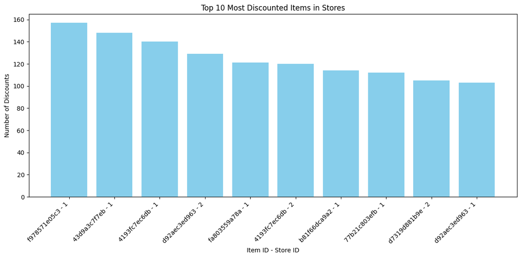

```python
# Count the number of discounts per item per store
discount_counts = df_merged.groupby(['item_id', 'store_id']).size().reset_index(name='discount_count')

# Sort the result to get the most discounted items
most_discounted = discount_counts.sort_values(by='discount_count', ascending=False).head(10)

# Create a bar plot for the most discounted items across stores
plt.figure(figsize=(12, 6))
bars = plt.bar(most_discounted['item_id'] + ' - ' + most_discounted['store_id'].astype(str),
               most_discounted['discount_count'],
               color='skyblue')

plt.xlabel('Item ID - Store ID')
plt.ylabel('Number of Discounts')
plt.title('Top 10 Most Discounted Items in Stores')
plt.xticks(rotation=45, ha='right')
plt.tight_layout()

plt.show()
```

### **5.2:** How do prices of items (price) vary across time (Year)?

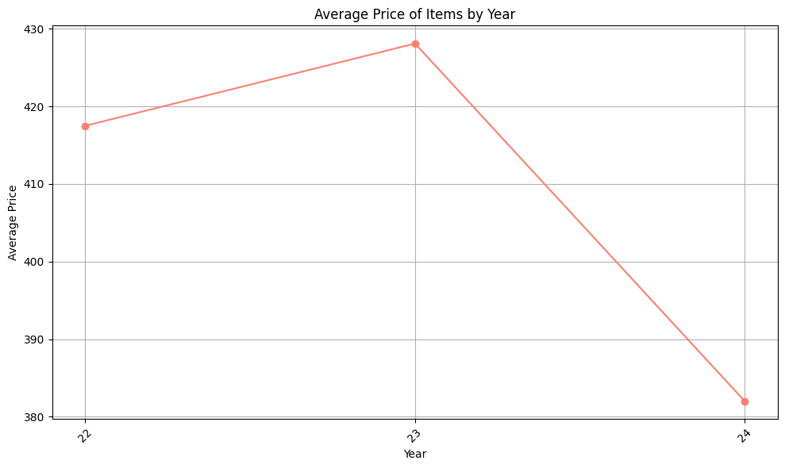

```python
# Group by year and calculate the average price
avg_price_by_year = df_merged.groupby('year')['price'].mean().reset_index()

# Plotting the price variation by year
plt.figure(figsize=(10, 6))
plt.plot(avg_price_by_year['year'], avg_price_by_year['price'], marker='o', color='salmon')

plt.title('Average Price of Items by Year')
plt.xlabel('Year')
plt.ylabel('Average Price')
plt.xticks(avg_price_by_year['year'], rotation=45)
plt.grid(True)
plt.tight_layout()
plt.show()
```

##### The plot shows that:

- The average price increased slightly from year 22 to year 23.
- There was a sharp decline in the average price from year 23 to year 24.

###### This suggests a possible shift in pricing strategies, increased discounts, or changes in the dataset for year 24.

### 5.3: Which stores (`store_id`) have the highest average item prices?

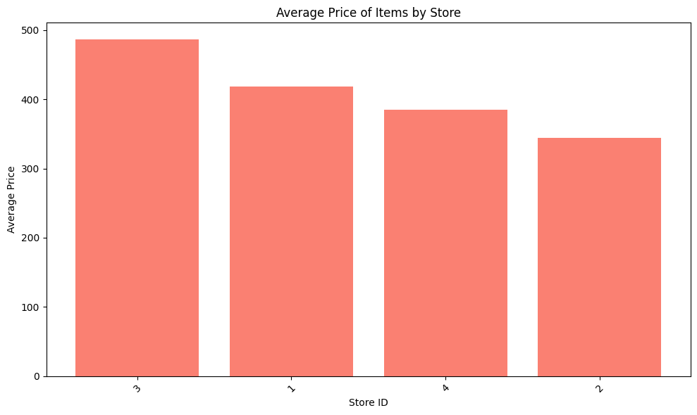

```python
# Group by store_id and calculate the average price
avg_price_by_store = df_merged.groupby('store_id')['price'].mean().reset_index()

# Sort by average price in descending order
avg_price_by_store = avg_price_by_store.sort_values(by='price', ascending=False)

# Plotting the average price by store using a bar plot
plt.figure(figsize=(10, 6))
plt.bar(avg_price_by_store['store_id'].astype(str), avg_price_by_store['price'], color='salmon')

plt.title('Average Price of Items by Store')
plt.xlabel('Store ID')
plt.ylabel('Average Price')
plt.xticks(rotation=45)
plt.tight_layout()
plt.show()
```

### **5.2:** Reflection

If I had more time, I would focus on investigating any potential issues with missing or duplicated data in both datasets to ensure the results are more accurate. I would also explore other research questions, such as analyzing the relationship between item categories and discount frequency, and how promotions affect sales performance over time. Additionally, I would consider examining how store-specific trends influence the effectiveness of discounts.